# Dataviz with ggplot2

Marcelino Guerra

Last update: 9/2/2020

Abstract

Lecture notes on how to make line plots and scatter plots with ggplot2, and an exercise with tidycensus.

## Line plots

In this exercise, we are working with urbanization and per capita income of a bunch of countries from [Our World in Data](https://ourworldindata.org/urbanization). The first chart is a simple line plot. The first step is to import [this .csv file](https://drive.google.com/file/d/1M13_5sjCNnouvGZOJB56SemHydPkgCvR/view?usp=sharing). You might want to check the data using `View()`.

```r
require(tidyverse)
urban_gdp<-read_csv("urbanization_gdp.csv", col_names=T)
```

Let’s check the evolution of the share of urban population (%) in Brazil, from 1950 to 2016. To do that, you need to filter the full dataset.

```r
brazil<-urban_gdp%>%filter(Entity=="Brazil")%>%arrange(Year)%>%filter(Year>=1950)
```

Working with the filtered data, use `ggplot()` package to create line plots. The package `ggthemes` allows you to customize the chart appearance, and you might want to check all the possibilites [here](https://yutannihilation.github.io/allYourFigureAreBelongToUs/ggthemes/). For this exercise, I will use [`theme_economist`](https://yutannihilation.github.io/allYourFigureAreBelongToUs/ggthemes/theme_economist/). The basic line plot works with `geom_line()`, and you can set the line type and its size easily. `theme()` adjust the size of the label in the axis, and `scale_x_continuous()` gives you some freedom to establish the years in the x axis (note that we are not working with dates yet!).

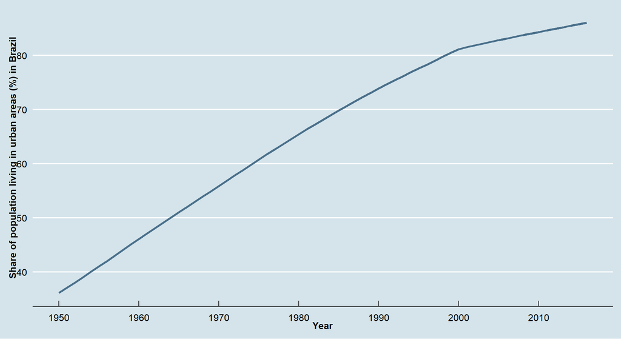

```r
library(ggthemes)

ggplot(data=brazil, aes(x=Year,y=`Share of population living in urban areas (%)`))+
  geom_line(size=1.4, color="skyblue4")+ labs(x = "Year", y="Share of population living in urban areas (%) in Brazil")+
  theme_economist(base_size = 14) +scale_colour_economist()+
  scale_x_continuous(breaks = seq(from = 1950, to =2016 , by =10))+
  theme(axis.text=element_text(size=12),
        axis.title=element_text(size=12,face="bold"))
```

## Scatter plots

Using scatter plots, you can see the degree of association between two variables. It is a very compelling way to show simple correlations. For example, one can argue that per capita income goes along with urbanization. To construct a scatter plot between those two variables for 2016, we filter the full dataset (`urban_gdp`) for 2016. You can check your new dataset using `View()`. There are entities without information about `GDP per capita` and we drop those NA’s together with the `Code` NA’s (here I am trying to get rid of entities that are not countries). Also, we drop the entity `World` because we want to work with countries.

As you can see, cleaning the data is a very important step. Finally, I will rename columns 4 and 5 and create a new variable using the natural logarithm of the GDP per capita.

```r
urban_gdp_16<-urban_gdp%>%filter(Year==2016)
urban_gdp_16<-urban_gdp_16%>%drop_na(Code, `GDP per capita (2011 int-$) ($)`)
urban_gdp_16<-urban_gdp_16%>%filter(Entity!="World")
names(urban_gdp_16)[4]<-"urban_pop"
names(urban_gdp_16)[5]<-"gdp"
urban_gdp_16$ln_gdp<-log(urban_gdp_16$gdp)
head(urban_gdp_16,3)
```

```
## # A tibble: 3 x 7
##   Entity      Code   Year urban_pop   gdp `Total population (Gapminder)` ln_gdp
##   <chr>       <chr> <dbl>     <dbl> <dbl>                          <dbl>  <dbl>
## 1 Afghanistan AFG    2016      25.0  1929                             NA   7.56
## 2 Albania     ALB    2016      58.4 11285                             NA   9.33
## 3 Algeria     DZA    2016      71.5 13328                             NA   9.50
```

Back to `ggplot()`, instead of `geom_line()` we use `geom_point()`. The package `ggrepel` allows you to label the dots in your chart (function `geom_text_repel()`), and `stat_smooth()` adds the regression line to your plot.

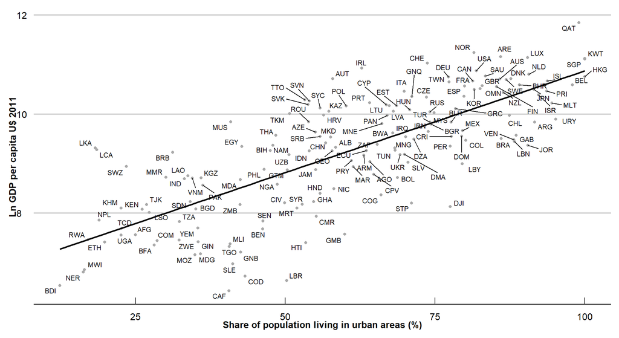

```r
library(ggrepel)

ggplot(urban_gdp_16, aes(x=urban_pop, y=ln_gdp)) + geom_point(color="darkgrey") + geom_text_repel(aes(label=Code), size=3)+
  stat_smooth(method = "lm", formula =y~x, se=F, color="black") +
  scale_x_continuous(name = "Share of population living in urban areas (%)") +
  scale_y_continuous(name = "Ln GDP per capita U$ 2011") +
  theme_economist_white(base_size = 17, gray_bg=FALSE)+
  theme(axis.text=element_text(size=12),
        axis.title=element_text(size=12,face="bold"))
```

## Tidycensus

To get started with `tidycensus`, you need to install the package and set a Census API key. Use this link [(here)](https://api.census.gov/data/key_signup.html) to request a key. You can use “University of Illinois at Urbana-Champaign” as an organization and your student account as an email address. After that, use `census_api_key("your_api_number_goes_here", install =TRUE)` and you are set. Let’s take a look at the variables in the American Community Survey 5-year estimates (`acs5`) for 2018.

```r
library(tidycensus)
#census_api_key("put_your_key_here", install =TRUE)
variables<- load_variables(year = 2018, dataset = "acs5")
head(variables)
```

```
## # A tibble: 6 x 3
##   name       label                                concept
##   <chr>      <chr>                                <chr>
## 1 B00001_001 Estimate!!Total                      UNWEIGHTED SAMPLE COUNT OF THE POPULATI~
## 2 B00002_001 Estimate!!Total                      UNWEIGHTED SAMPLE HOUSING UNITS
## 3 B01001_001 Estimate!!Total                      SEX BY AGE
## 4 B01001_002 Estimate!!Total!!Male                SEX BY AGE
## 5 B01001_003 Estimate!!Total!!Male!!Under 5 years SEX BY AGE
## 6 B01001_004 Estimate!!Total!!Male!!5 to 9 years  SEX BY AGE
```

Working with `tidycensus`, you can get data from a collection of geographies - state, county, block, tract, etc. Here we work with tracts in Suffolk County-MA (Boston region) for 2018. All the variables have an specific code and you might want to come back to `variables` to check what is available and what code corresponds to what variables.

```r
boston_data <- get_acs(geography = "tract", state="MA", county = "Suffolk County", year=2018, dataset="acs5", output = "wide", variables = c(medincome="B19013_001", housevalue="B25077_001", rent="B25064_001", age= "B01002_001"))
head(boston_data)
```

```
## # A tibble: 6 x 10
##   GEOID  NAME        medincomeE medincomeM housevalueE housevalueM rentE rentM  ageE  ageM
##   <chr>  <chr>            <dbl>      <dbl>       <dbl>       <dbl> <dbl> <dbl> <dbl> <dbl>
## 1 25025~ Census Tra~     132750      21851      592900       52186  1919   257  31.4   1.7
## 2 25025~ Census Tra~      12759       2688          NA          NA   344    48  29.4   2.6
## 3 25025~ Census Tra~      84083      29464      945100      146026  2301   479  31.7   2
## 4 25025~ Census Tra~      28851       7215     1080400      411408  1008   256  39.4   5.6
## 5 25025~ Census Tra~      52676      19924      758100      100425    NA    NA  37     4.2
## 6 25025~ Census Tra~      53649      16565      715200      293919   623   350  36.4   6.5
```

The `E` after the variable’s name corresponds to “estimate” - that is the value we are looking for. The `M` after the variable’s name refers to the margin of error - [here](https://www.census.gov/programs-surveys/acs/guidance/training-presentations/acs-moe.html) you have more info about the moe. With the following code, you get a scatter plot of median household income and median gross rent for census tracts in Boston-MA.

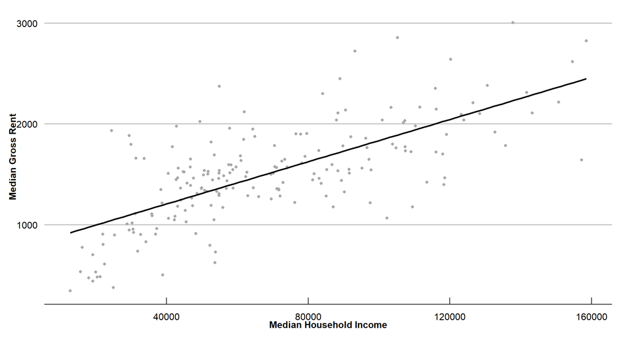

```r
ggplot(boston_data, aes(x=medincomeE, y=rentE)) + geom_point(color="darkgrey")+
  stat_smooth(method = "lm", formula =y~x, se=F, color="black") +
  scale_x_continuous(name = "Median Household Income") +
  scale_y_continuous(name = "Median Gross Rent")+
  theme_economist_white(base_size = 17, gray_bg=FALSE)+
  theme(axis.text=element_text(size=12),
        axis.title=element_text(size=12,face="bold"))
```